# Ruler Analysis for Bee Project

KM Thomasson

9/13/2021

`Data` / `Results Summary` / `Appendex`

## Introduction

An important component of the starting phases of the Big-Bee project is the formulation of a consistent protocol for imaging specimens with labels. As part of this protocol, we needed to determine which measurement tool would be both accessible, accurate and precise for all participants. For this reason, we performed an initial assessment of five standard rulers using a microscope reticle as a comparison.

The five measurement were from four rulers which were available for purchase online:

```r
#Forestry Ruler which costs about $1.25
#Forensics Ruler which costs about $2
#Builders Ruler which costs about $35 (For this Ruler two measurements were taken to determine if specific calibration points, 1.5 and 3.5, yielded differences in accuracy on the same tool.
#Microscope slide ruler which costs about $14
```

## Data

The (CSV file)[https://github.com/Big-Bee-Network/ruler-analysis/blob/main/bee_ruler_main.csv] for this analysis

The images used for this study are found here: https://ucsb.box.com/s/tvw67tqc4msiiae6aw0kaodpuilf3zld

Species used in this analysis ranged in body size and hariness. Those species are *Lasioglossum incompletum* (Halictidae), *Lasioglossum sisymbrii* (Halictidae), *Osmia brevis* (Megachilidae), *Ceratina arizonensis* (Apidae), *Xylocopa varipuncta* (Apidae), *Anthophora californica* (Apidae), *Hylaeus polifoli* (Colletidae), *Megachile fidelis* (Megachilidae), *Andrena chlorogaster* (Andrenidae), *Peponapis pruinosa* (Apidae), *Calliopsis* sp. (Andrenidae), *Bombus melanopygus*, *B. sonorus*, *B. vosnesenskii* (Apidae), *Agapostemon texanus* (Halictidae), *Sphecodes* sp. (Halictidae), *Augochlorella pomoniella* (Halictidae), *Xeromelecta californica* (Apidae), *Trachusa perdita* (Megachilidae), *Colletes* sp. (Colletidae)

## Analysis

For the analysis, three different individuals (Researchers) measured the intertegular span using Image J software and calibrating the software using the selected measurement tools. A microscope reticle was also used as a standard and all measurements were compared against this standard. Researchers also recorded hairiness (hairy, not hairy), pigment (light, dark), and size (tiny, very small, small, medium, large) characteristics because of their potential to affect measurement accuracy. Data was collected and then separated by Measurement type and Recorder. A paired analysis was then performed by finding the difference in measurement from each measurement tool relative to the standard (reticle) for each specimen. The variance of the resultant values were then analyzed for differences in sample mean and variance relative to zero (the mean and variance of the reticle values set to zero).

```r
B_Rulers_complete <-read.csv("bee_ruler_main.csv")
B_Rulers0 <-subset(B_Rulers_complete, select = -c(8,13))
colnames(B_Rulers0)<-c("Barcode", "Recorder", "ForestryR", "ForensicsR", "MicroscopeR", "Builder1.5R", "Builder3.5R", "Red1x_Micro_R", "Pigment", "Hair", "Size")
B_Rulers_main <- B_Rulers0 %>%
  mutate(Forestry = ForestryR - Red1x_Micro_R,
         Forensics = ForensicsR - Red1x_Micro_R,
         Microscope = MicroscopeR - Red1x_Micro_R,
         Builder1.5 = Builder1.5R - Red1x_Micro_R,
         Builder3.5 = Builder3.5R - Red1x_Micro_R,
         Red1x_Micro = Red1x_Micro_R- Red1x_Micro_R)

B_Rulers0.5 <-subset(B_Rulers_main, select = -c(3:7))
B_Rulers1 <- B_Rulers0.5[ , c("Barcode", "Recorder" , "Pigment" , "Hair", "Size", "Red1x_Micro", "Forestry", "Forensics", "Microscope", "Builder1.5", "Builder3.5")]
head(B_Rulers1)
```

```
##            Barcode Recorder  Pigment         Hair                         Size
## 1 UCSB-IZC00005866       AW  1- dark 0- not hairy                     2- small
## 2 UCSB-IZC00009088       AW 0- light     1- hairy                     4- large
## 3 UCSB-IZC00009810       AW  1- dark     1- hairy                    3- medium
## 4 UCSB-IZC00009824       AW  1- dark     1- hairy                     4- large
## 5 UCSB-IZC00010359       AW 0- light     1- hairy                    3- medium
## 6 UCSB-IZC00015111       AW 0- light     1- hairy 1- slightly larger than tiny
##   Red1x_Micro Forestry Forensics Microscope Builder1.5 Builder3.5
## 1           0    0.188     0.083      0.212      0.191      0.193
## 2           0   -0.006     0.285      0.300      0.216     -0.094
## 3           0    0.258     0.209      0.260      0.404     -0.084
## 4           0    0.991     1.027      1.105      1.198      1.160
## 5           0    0.781     0.845      0.648      0.668      0.692
## 6           0   -0.251    -0.207     -0.193     -0.024     -0.127
```

```r
B_Rulers2<-pivot_longer(B_Rulers1, col=6:11, names_to="Type", values_to="Measurement")
head(B_Rulers2)
```

```
## # A tibble: 6 × 7
##   Barcode          Recorder Pigment Hair         Size     Type        Measurement
##   <chr>            <chr>    <chr>   <chr>        <chr>    <chr>             <dbl>
## 1 UCSB-IZC00005866 AW       1- dark 0- not hairy 2- small Red1x_Micro      0
## 2 UCSB-IZC00005866 AW       1- dark 0- not hairy 2- small Forestry         0.188
## 3 UCSB-IZC00005866 AW       1- dark 0- not hairy 2- small Forensics        0.0830
## 4 UCSB-IZC00005866 AW       1- dark 0- not hairy 2- small Microscope       0.212
## 5 UCSB-IZC00005866 AW       1- dark 0- not hairy 2- small Builder1.5       0.191
## 6 UCSB-IZC00005866 AW       1- dark 0- not hairy 2- small Builder3.5       0.193
```

Comparison of the variance and mean for all the data separated by measurement tool and the data of each researcher by measurement tool shows the deviance of each value from zero.

```r
Kat<-subset(B_Rulers1, Recorder=="KS")
Zoe<-subset(B_Rulers1, Recorder=="ZW")
Adam<-subset(B_Rulers1, Recorder=="AW")
summary(B_Rulers1)
```

```
##    Barcode            Recorder           Pigment              Hair
##  Length:66          Length:66          Length:66          Length:66
##  Class :character   Class :character   Class :character   Class :character
##  Mode  :character   Mode  :character   Mode  :character   Mode  :character
##
##
##
##      Size            Red1x_Micro    Forestry          Forensics
##  Length:66          Min.   :0    Min.   :-0.25400   Min.   :-0.3350
##  Class :character   1st Qu.:0    1st Qu.:-0.00425   1st Qu.:-0.0380
##  Mode  :character   Median :0    Median : 0.08600   Median : 0.0825
##                     Mean   :0    Mean   : 0.18726   Mean   : 0.1597
##                     3rd Qu.:0    3rd Qu.: 0.30075   3rd Qu.: 0.2770
##                     Max.   :0    Max.   : 1.19600   Max.   : 1.0270
##    Microscope         Builder1.5        Builder3.5
##  Min.   :-0.19300   Min.   :-0.2330   Min.   :-0.2010
##  1st Qu.:-0.03575   1st Qu.:-0.0175   1st Qu.:-0.0520
##  Median : 0.08750   Median : 0.1185   Median : 0.1040
##  Mean   : 0.17398   Mean   : 0.2052   Mean   : 0.2257
##  3rd Qu.: 0.27400   3rd Qu.: 0.4020   3rd Qu.: 0.3650
##  Max.   : 1.10500   Max.   : 1.1980   Max.   : 1.5470
```

```r
summary(B_Rulers2)
```

```
##    Barcode            Recorder           Pigment              Hair
##  Length:396         Length:396         Length:396         Length:396
##  Class :character   Class :character   Class :character   Class :character
##  Mode  :character   Mode  :character   Mode  :character   Mode  :character
##
##
##
##      Size               Type            Measurement
##  Length:396         Length:396         Min.   :-0.3350
##  Class :character   Class :character   1st Qu.:-0.0015
##  Mode  :character   Mode  :character   Median : 0.0400
##                                        Mean   : 0.1586
##                                        3rd Qu.: 0.2362
##                                        Max.   : 1.5470
```

```r
Mean1 <-c(mean(B_Rulers1$Forestry),mean(B_Rulers1$Forensics),mean(B_Rulers1$Microscope), mean(B_Rulers1$Builder1.5), mean(B_Rulers1$Builder3.5), mean(B_Rulers1$Red1x_Micro))
Variance1 <-c(var(B_Rulers1$Forestry), var(B_Rulers1$Forensics), var(B_Rulers1$Microscope), var(B_Rulers1$Builder1.5), var(B_Rulers1$Builder3.5), var(B_Rulers1$Red1x_Micro))
KatVar <- c(var(Kat[7]), var(Kat[8]), var(Kat[9]), var(Kat[10]), var(Kat[11]),var(Kat[6]))
ZoeVar<- c(var(Zoe[7]), var(Zoe[8]), var(Zoe[9]), var(Zoe[10]), var(Zoe[11]), var(Zoe[6]))
AdVar<- c(var(Adam[7]), var(Adam[8]), var(Adam[9]), var(Adam[10]), var(Adam[11]), var(Adam[6]))
Var_Cats <- matrix(c(Mean1, Variance1, KatVar, ZoeVar, AdVar), ncol=6, byrow=TRUE)
colnames(Var_Cats) <- c("Forestry", "Forensics", "Microscope", "Builder1.5", "Builder3.5", "Red1x_Micro")
rownames(Var_Cats) <- c('Mean', 'Variance','R1 Var','R2 Var','R3 Var')
var_cats <- as.table(Var_Cats)
var_cats
```

```
##            Forestry  Forensics Microscope Builder1.5 Builder3.5 Red1x_Micro
## Mean     0.18725758 0.15972727 0.17398485 0.20519697 0.22565152  0.00000000
## Variance 0.10343730 0.09939236 0.08975312 0.11734764 0.15311808  0.00000000
## R1 Var   0.10501127 0.10167235 0.09204817 0.12255775 0.16579517  0.00000000
## R2 Var   0.10501127 0.10167235 0.09204817 0.12255775 0.16579517  0.00000000
## R3 Var   0.10217157 0.10251076 0.09080128 0.11520190 0.12387314  0.00000000
```

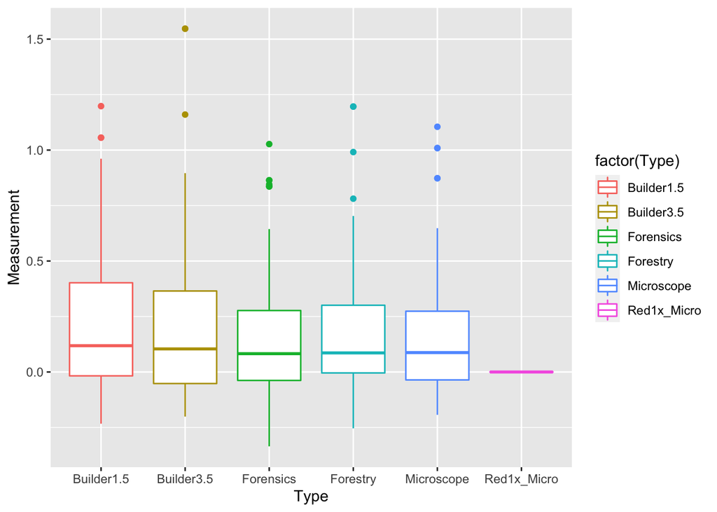

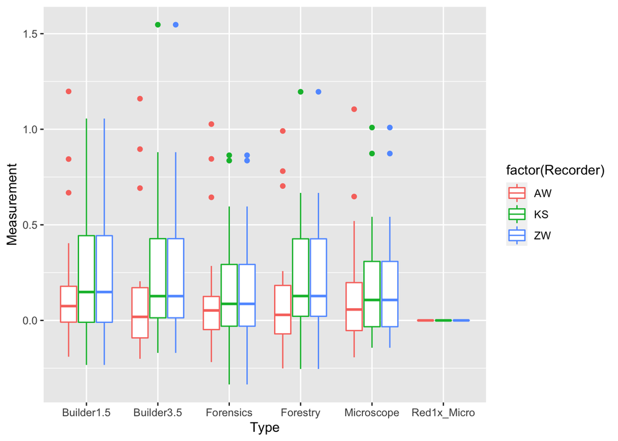

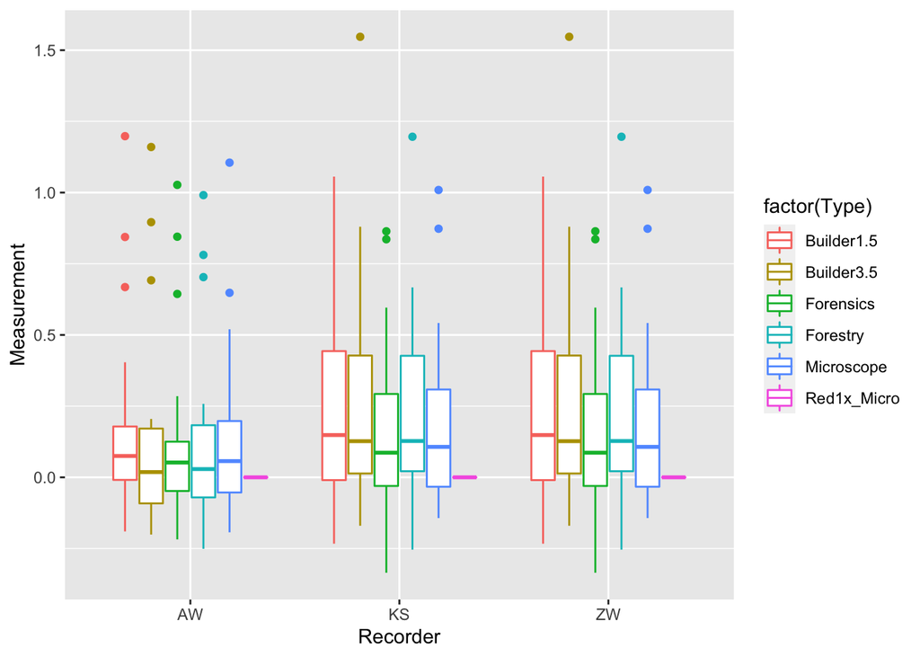

The affect of characteristics on variance of measurement indicated that variance relative to the standard increases as the size of the bee increases (Figures 4 and 5) and the presence of hair increases variance as well (Figures 6 and 7). These two factors may be confounded as bee hairiness affects the perception of bee size. Bee pigment did not consistently affect variance relative to the standard for the Recorder or by the measurement type (Figures 8 and 9).

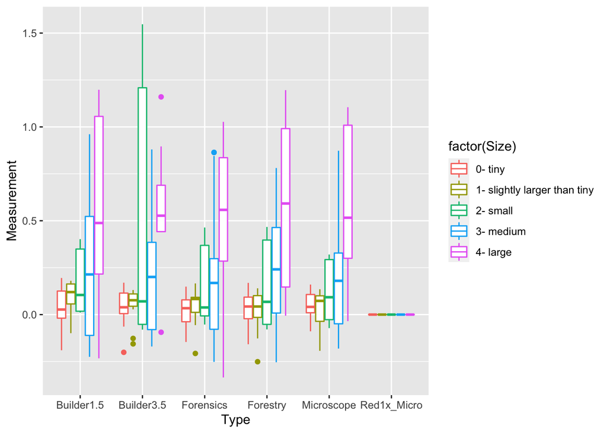

```r
Plot4 <-ggplot(data = B_Rulers2) +
  geom_boxplot(data = B_Rulers2, aes(Type, Measurement, color = factor(Size)))
Plot4
```

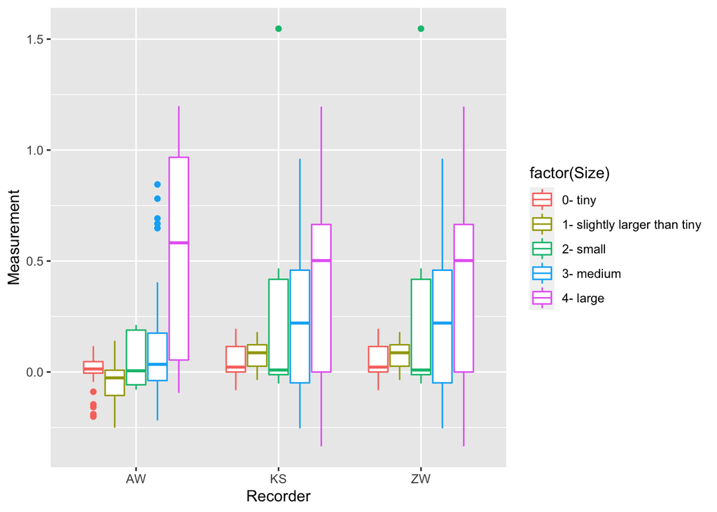

```r
Plot5 <-ggplot(data = B_Rulers2) +
  geom_boxplot(data = B_Rulers2, aes(Recorder, Measurement, color = factor(Size)))
Plot5
```

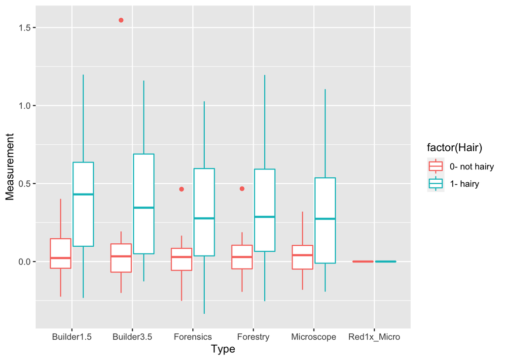

```r
Plot6 <-ggplot(data = B_Rulers2) +
  geom_boxplot(data = B_Rulers2, aes(Type, Measurement, color = factor(Hair)))
Plot6
```

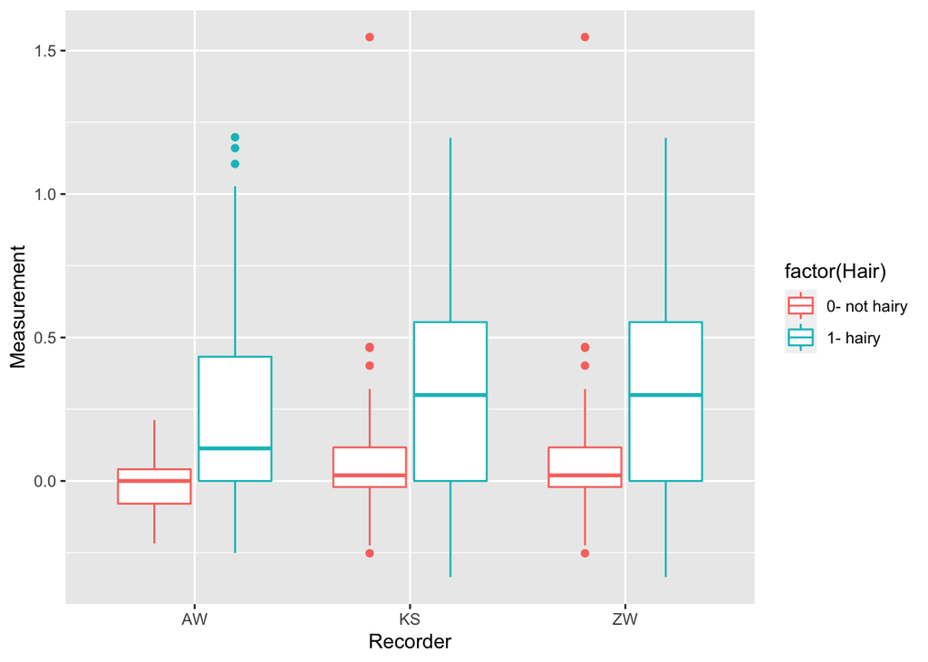

```r
Plot7 <-ggplot(data = B_Rulers2) +
  geom_boxplot(data = B_Rulers2, aes(Recorder, Measurement, color = factor(Hair)))
Plot7
```

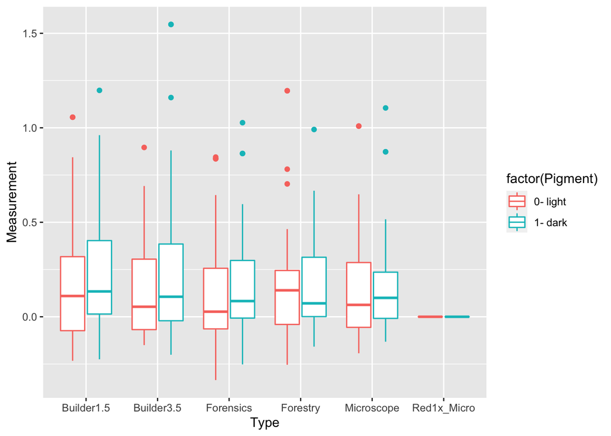

```r
Plot8 <-ggplot(data = B_Rulers2) +
  geom_boxplot(data = B_Rulers2, aes(Type, Measurement, color = factor(Pigment)))
Plot8
```

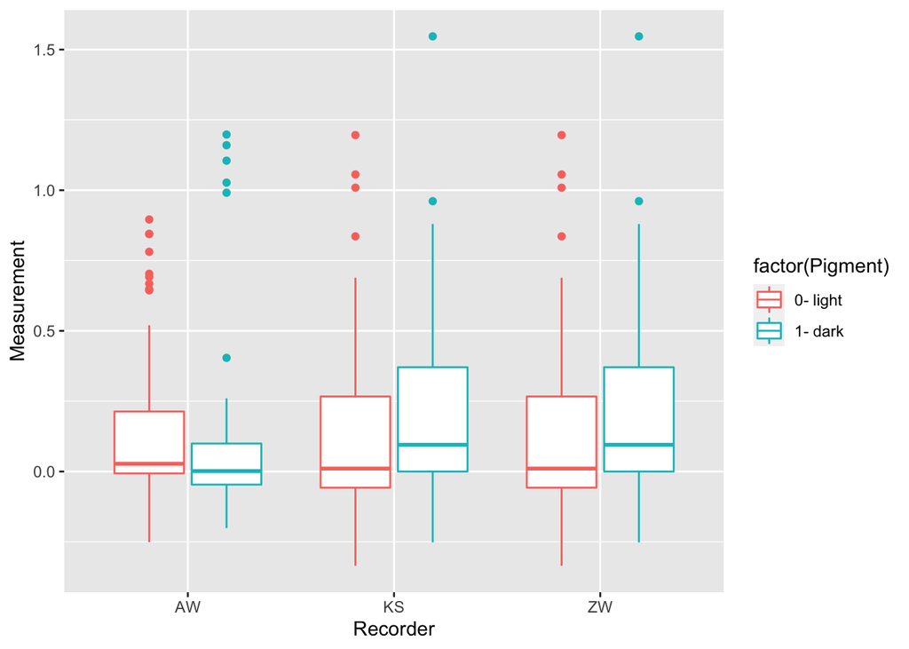

```r
Plot9 <-ggplot(data = B_Rulers2) +
  geom_boxplot(data = B_Rulers2, aes(Recorder, Measurement, color = factor(Pigment)))
Plot9
```

These findings were substantiated with an ANOVA test using measurement type and recorder as factors in the resultant measurement values, and summarization of a GLM of the effects of measurement tool, recorder and bee body characteristics (Size, Hair, Pigment) and a semi-factorial assay of the interactions of these attributes (See line below). These results are initial and a secondary analysis with a larger sample size will be performed in the future. For now these results offer guidelines for analysis and estimation.

## Results Summary

The general linear model indicated that there was significant variance from the standard when the bee was hairy (P Value 0.00475) and when the bee was both large and dark or large and hairy for some recorders (dark and large P values <0.001 and dark and hairy P values <0.005 for two researcher).

Builders are more expensive rulers and do not offer clear decreased variance from the standard. Researchers reported liking the Forensics Ruler, Calibrator’s Microscope Ruler and the Builder’s Ruler. Researchers that reported liking the Builders Ruler had no preference in the 1.5 or 3.5 calibration markers. The Forestry Ruler was the least liked by Researchers.

## Appendex

```r
summary(aov(Measurement ~ Recorder, data = B_Rulers2))
```

```
##              Df Sum Sq Mean Sq F value Pr(>F)
## Recorder      2   0.49 0.24645    2.53 0.0809 .
## Residuals   393  38.28 0.09739
## ---
## Signif. codes:  0 '***' 0.001 '**' 0.01 '*' 0.05 '.' 0.1 ' ' 1
```

```r
summary(aov(Measurement ~ Type, data = B_Rulers2))
```

```
##              Df Sum Sq Mean Sq F value   Pr(>F)
## Type          5   2.17  0.4340   4.625 0.000411 ***
## Residuals   390  36.60  0.0938
## ---
## Signif. codes:  0 '***' 0.001 '**' 0.01 '*' 0.05 '.' 0.1 ' ' 1
```

```r
BEES1 <-glm(Measurement ~ Recorder + Type + Pigment + Size + Hair + Pigment*Size*Hair + Recorder*Type + Type*Pigment + Type*Size + Type*Hair + Type*Hair*Size*Pigment+ Recorder*Size*Hair*Pigment, data = B_Rulers2)
summary(BEES1)
```

```
##
## Call:
## glm(formula = Measurement ~ Recorder + Type + Pigment + Size +
##     Hair + Pigment * Size * Hair + Recorder * Type + Type * Pigment +
##     Type * Size + Type * Hair + Type * Hair * Size * Pigment +
##     Recorder * Size * Hair * Pigment, data = B_Rulers2)
##
## Deviance Residuals:
##      Min        1Q    Median        3Q       Max
## -0.69343  -0.07240  -0.00117   0.06554   0.93151
##
## Coefficients: (64 not defined because of singularities)
##                                                                                Estimate
## (Intercept)                                                                   3.937e-02
## RecorderKS                                                                   -8.855e-02
## RecorderZW                                                                   -8.855e-02
## TypeBuilder3.5                                                               -7.079e-02
## TypeForensics                                                                -1.209e-02
## TypeForestry                                                                 -4.758e-02
## TypeMicroscope                                                               -2.394e-03
## TypeRed1x_Micro                                                               6.264e-02
## Pigment1- dark                                                               -2.925e-02
## Size1- slightly larger than tiny                                              8.000e-03
## Size2- small                                                                  3.236e-02
## Size3- medium                                                                -2.256e-01
## Size4- large                                                                 -1.292e-01
## Hair1- hairy                                                                  5.220e-01
## Pigment1- dark:Size1- slightly larger than tiny                               8.750e-03
## Pigment1- dark:Size2- small                                                          NA
## Pigment1- dark:Size3- medium                                                  5.636e-02
## Pigment1- dark:Size4- large                                                   7.479e-01
## Pigment1- dark:Hair1- hairy                                                  -1.081e-01
## Size1- slightly larger than tiny:Hair1- hairy                                -6.000e-01
## Size2- small:Hair1- hairy                                                            NA
## Size3- medium:Hair1- hairy                                                           NA
## Size4- large:Hair1- hairy                                                            NA
## RecorderKS:TypeBuilder3.5                                                     9.818e-02
## RecorderZW:TypeBuilder3.5                                                     9.818e-02
## RecorderKS:TypeForensics                                                     -1.386e-02
## RecorderZW:TypeForensics                                                     -1.386e-02
```

[output cut: 822 more lines]

```
## RecorderZW:Pigment1- dark:Size2- small:Hair1- hairy
## RecorderKS:Pigment1- dark:Size3- medium:Hair1- hairy
## RecorderZW:Pigment1- dark:Size3- medium:Hair1- hairy
## RecorderKS:Pigment1- dark:Size4- large:Hair1- hairy
## RecorderZW:Pigment1- dark:Size4- large:Hair1- hairy
## ---
## Signif. codes:  0 '***' 0.001 '**' 0.01 '*' 0.05 '.' 0.1 ' ' 1
##
## (Dispersion parameter for gaussian family taken to be 0.0567957)
##
##     Null deviance: 38.768  on 395  degrees of freedom
## Residual deviance: 16.471  on 290  degrees of freedom
## AIC: 78.587
##
## Number of Fisher Scoring iterations: 2
```